# MA5832-Capstone Report

David Griffith

16/06/2020

## Australian Unemployment Rate

Unemployment rates over the last 40 years in Australia have decreased from **5.77%** in 1980 to **5.16%** at the end of 2019. While this may not seem like a lot, what should be taken into consideration is the population growth of Australia when analysing these numbers. The population of Australia was *14.69 million* in 1980 and in 2019 it reached **25.20 million**. Thats an increase of **10.51 million** people in the 40 year time period or a population growth of **71.5%**.

Another metric that should be considered when analysing unemployment rates is *employment rates*. In the same 40 year period, the number of people employed in Australia has increased from **6,112,917** to **12,434,267** which is a growth of **103%**. This makes sense as the unemployment rates are falling, the population is growing and the number of people employed is also growing.

### Employment Rate

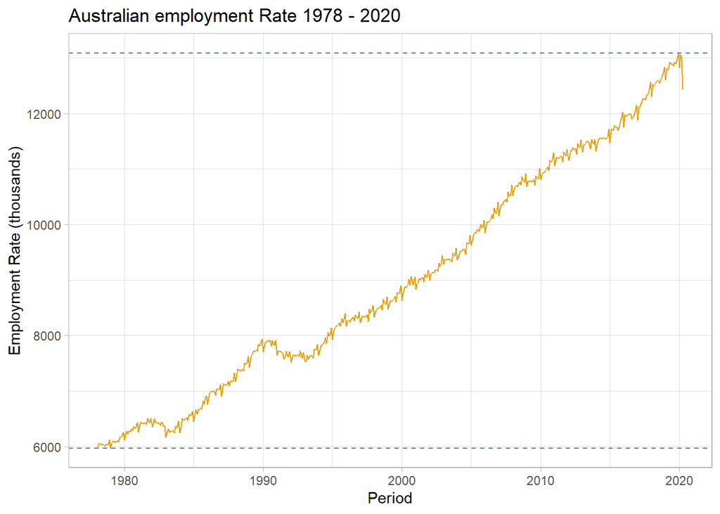

### Job Vacancy Rate

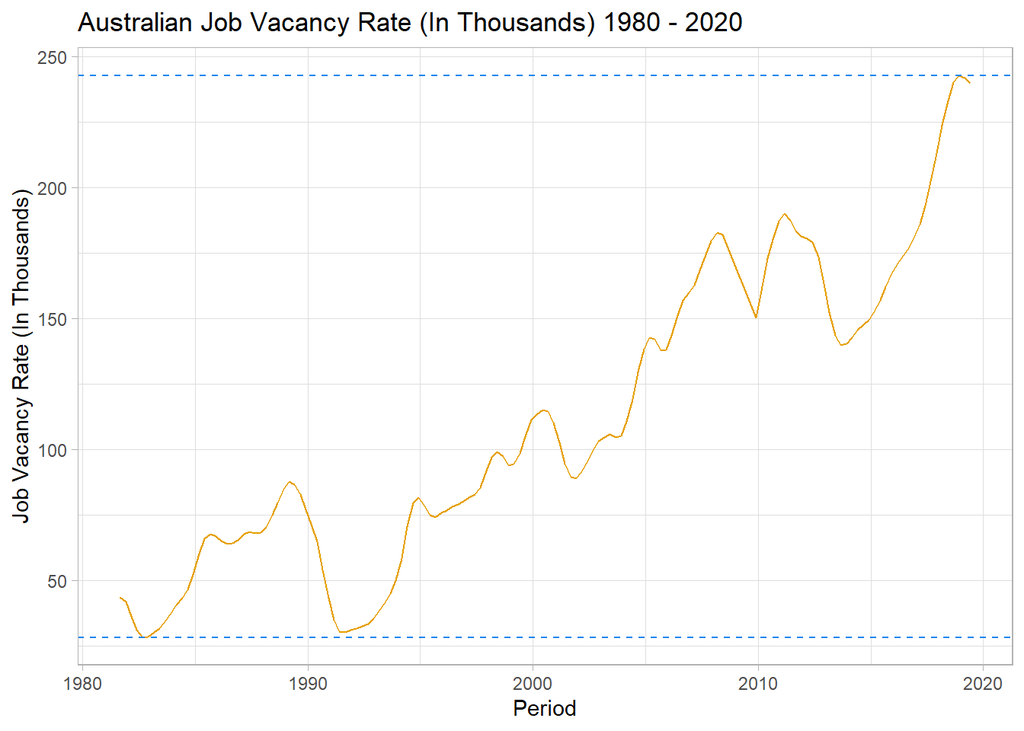

Diving deeply into the verticals of all confounding aspects into unemployment is not in the scope of this report, however it is worth detailing why the sudden increase in unemployment occurred in 1990. This increase saw unemployment rates skyrocket from 6% to over 11% in the few years after.

In 1990 Australia was officially declared to be in a recession and the then, treasurer Paul Keating has been famously quoted saying “This is a recession that Australia had to have”. This obviously correlates to an increase in unemployment rates as the highest point of Australian unemployment within the last 40 years was a short few years after this.

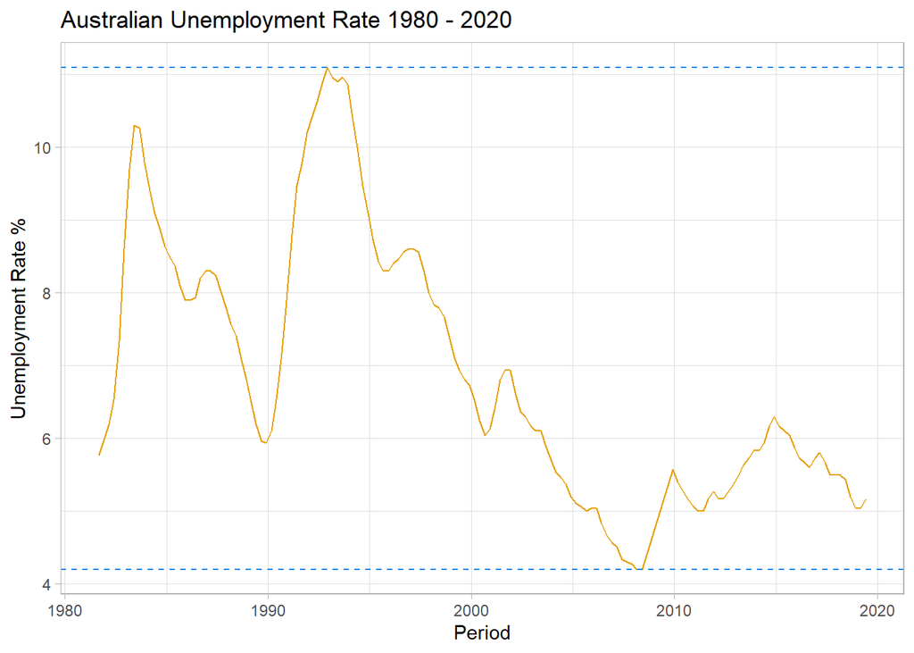

Also observed in the data is a correlation between **GDP** and **Unemployment Rates**. A professor by the name of *Arthur Okun* postulated this relationship between economic growth and jobs in the 1960’s and drew the conclusion that a country’s gross domestic product (GDP) must grow at about a 4% rate for one year to achieve a 1% reduction in the rate of unemployment. While there is a difference in percentage points for the Australian economy over the last 40 years, there does appear to be some correlation as shown in the plot below.

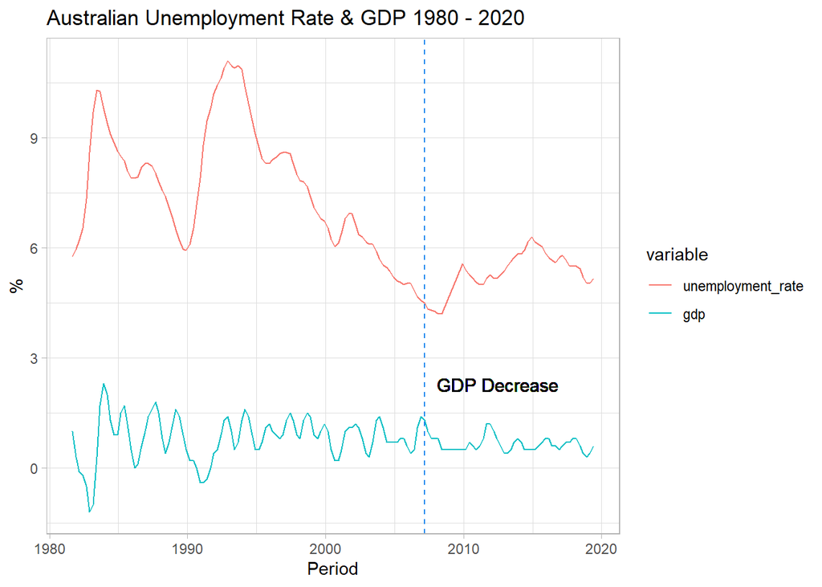

## Data

The data used in the capstone is aggregated and collected from the Australian Bureau of Statistics (ABS). The data is available quarterly from June 1981 to December 2019.

| period | unemployment_rate | gdp | general_final_consumption_expenditure | all_final_consumption_expenditure | terms_of_trade_index | cpi | job_vacancies | estimated_res_population |
| --- | --- | --- | --- | --- | --- | --- | --- | --- |
| 1981-09-01 | 5.766667 | 1.0 | -0.8 | 1.0 | -0.7 | 29.0 | 43.8 | 14988.7 |
| 1981-12-01 | 5.966667 | 0.3 | -1.0 | 0.7 | -1.5 | 30.2 | 41.8 | 15054.1 |
| 1982-03-01 | 6.200000 | -0.1 | -0.7 | 0.6 | -1.1 | 30.8 | 36.4 | 15121.7 |
| 1982-06-01 | 6.533333 | -0.2 | 0.3 | 0.9 | -0.3 | 31.5 | 31.2 | 15184.2 |
| 1982-09-01 | 7.333333 | -0.5 | 1.8 | 1.1 | 0.2 | 32.6 | 28.4 | 15239.3 |
| 1982-12-01 | 8.600000 | -1.2 | 1.6 | 0.6 | 0.0 | 33.6 | 28.6 | 15288.9 |

The data includes the response variable (unemployment rate) and 7 predictors with different data types which can be observed below:

| column_name | data_type |
| --- | --- |
| period | date |
| unemployment_rate | numerical % |
| gdp | numerical % |
| general_final_consumption_expenditure | numerical % |
| all_final_consumption_expenditure | numerical % |
| terms_of_trade_index | numerical % |
| cpi | numerical % |
| job_vacancies | numerical (thousands) |
| estimated_res_population | numerical (thousands) |

### Interventions and or/pre processing

A number of data wrangling techniques have been used to prepare the data for modelling. Variable names have been updated, type conversion has been made and NA’s have been removed as to not impact the models. The data has also been scaled using the base R function **scale()**. For interpret-ability of the predicted results the data has then been translated back to original scale of the data.

### Correlations

We can observe the Pearson correlation between variables in the below heat-map. **Unemployment** clearly has a negative **correlation** between **job_vacancies**, **population** and **cpi**. What is interesting that there doesn’t appear to be any form of correlation with **GDP** and the **unemployment_rate** variable in relation to *Okuns Law* which was discussed earlier. You are able to observe a potential negative correlation between the two in the plot above however it is not found using the Pearson correlation formula. Further investigation outside the scope of this report could be conducted to further validate this.

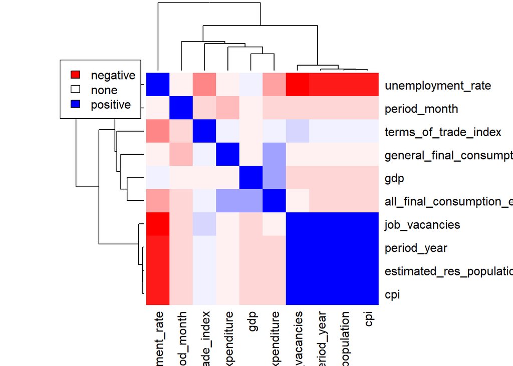

### Scaling

Data was scaled using the base **scale()** function as can be observed below. The scale function centers (subtracts mean value), and then scales (divides by standard deviation of data).

| unemployment_rate | gdp | general_final_consumption_expenditure | all_final_consumption_expenditure | terms_of_trade_index | cpi | job_vacancies | estimated_res_population | period_year | period_month |
| --- | --- | --- | --- | --- | --- | --- | --- | --- | --- |
| -0.6596981 | 0.4382905 | -2.578232 | 0.5611898 | -0.4980902 | -1.831746 | -1.160117 | -1.513695 | -1.688000 | 0.4475078 |
| -0.5485088 | -0.8999911 | -2.899964 | -0.2777414 | -0.8414397 | -1.782250 | -1.195591 | -1.491479 | -1.688000 | 1.3364759 |
| -0.4187879 | -1.6647235 | -2.417366 | -0.5573851 | -0.6697649 | -1.757501 | -1.291370 | -1.468515 | -1.597768 | -1.3304285 |
| -0.2334724 | -1.8559066 | -0.808707 | 0.2815461 | -0.3264155 | -1.728628 | -1.383601 | -1.447285 | -1.597768 | -0.4414604 |
| 0.2112849 | -2.4294558 | 1.604282 | 0.8408335 | -0.1118221 | -1.683256 | -1.433264 | -1.428567 | -1.597768 | 0.4475078 |
| 0.9154839 | -3.7677374 | 1.282550 | -0.5573851 | -0.1976595 | -1.642009 | -1.429717 | -1.411718 | -1.597768 | 1.3364759 |

### Subsetting

```r
# Create training and test data sets

set.seed(112)
training_data <- unemployment_data_scaled[1:129,]
test_data <- unemployment_data_scaled[130:147,]
```

### Distribution

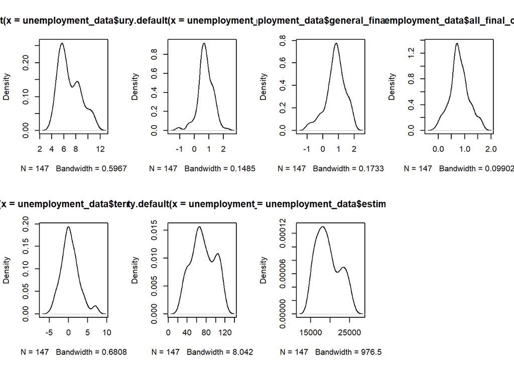

## Machine Learning

### Support Vector Regression (SVR)

As part of this analysis the Support Vector Regression (SVR) model has been chosen as the model of choice. SVR are similar to SVM’s however they work to minimise the coefficients.

Root Mean Squared Error is what has been used as a means of assessing model accuracy.

The calculation for this is as follows:

```r
rmse <- function(errval)
{
  val = sqrt(mean(errval^2))
  return(val)
}
```

With errval being a variable of the error rate between $\hat{y} - y$

A couple of reasons why i chose this model over others:

- Learning opportunity as i have no experience with the SVR
- Random Forests can be prone to over fitting and there isn’t a significant amount of data to work with for this analysis.
- The data used for the regression modelling may not be linearly separable. SVR models have the ability to work with non linear kernels, all of which have been tested below.

We can train the initial model on the training data which we have subsetted and scaled.

```r
set.seed(112)
svm_model <- svm(unemployment_rate~., data = training_data)
svm_predict_training <- predict(svm_model, training_data)
```

As mentioned above, the Root Mean Squared Error (RMSE) has been calculated as a way of determining model accuracy.

$R M S E=\sqrt{\sum_{i=1}^{n} \frac{\left(\hat{y}_{i}-y_{i}\right)^{2}}{n}}$

We calculate the error rate of the model by subtracting the actual value from the predicted value and then passing it into the **rmse()** function. We can see below that the RMSE of the model on the training data is equal to **0.3101003**.

```r
svm_error <- svm_predict_training - training_data$unemployment_rate
svm_RMSE <- rmse(svm_error)
svm_RMSE
```

```
## [1] 0.3101003
```

### Cost

The SVM model has a cost function, which controls training errors and margins. a large value of Cost parameter indicates poor accuracy but low bias and vice-versa. The bias variance trade off is always an important consideration in any ML process. The optimal cost value for this model was **5** and was selected using the code below:

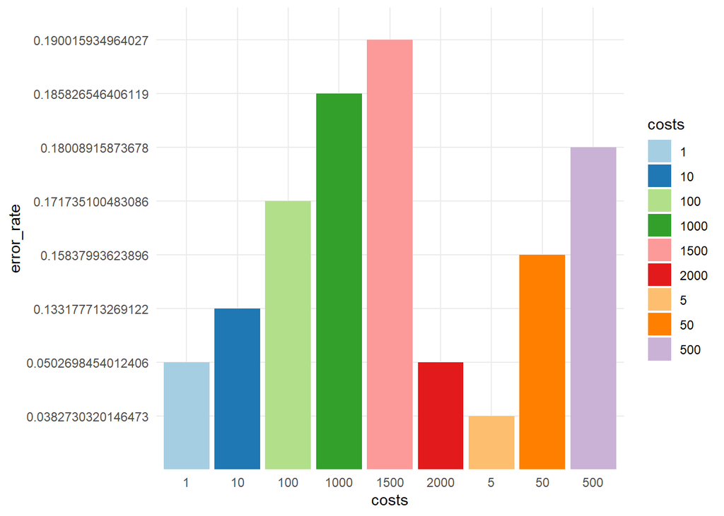

```r
# Try different cost to see if model accuracy can be further improved

costs <- c("1", "5", "10", "50", "100", "500", "1000", "1500", "2000")
svm_model_cost <- list()
predict_test_cost <- list()
error_cost <- NULL
svm_RMSE_cost <- NULL
i = 0
suppressWarnings(
for (cost in costs) {

  svm_model_cost <- svm(unemployment_rate~., data = training_data, cost = cost)
  predict_test_cost <- predict(svm_model_cost, test_data)

  # store errors

  error_cost[i] <- predict_test_cost - test_data$unemployment_rate
  svm_RMSE_cost[i] <- rmse(error_cost)
  i = i+1

}
)
cost_error_df <- data.frame(cbind(costs, svm_RMSE_cost))
colnames(cost_error_df)[2] <- "error_rate"
cost_error_df$costs <- as.factor(cost_error_df$costs)
cost_error_df$error_rate <- as.factor(cost_error_df$error_rate)


cost_error_df <- cost_error_df %>%
  arrange(error_rate)

ggplot(cost_error_df, aes(x = costs, y = error_rate, fill = costs)) +
  geom_bar(stat = "identity") +
  scale_fill_brewer(palette="Paired") +
theme_minimal()
```

### Epsilon

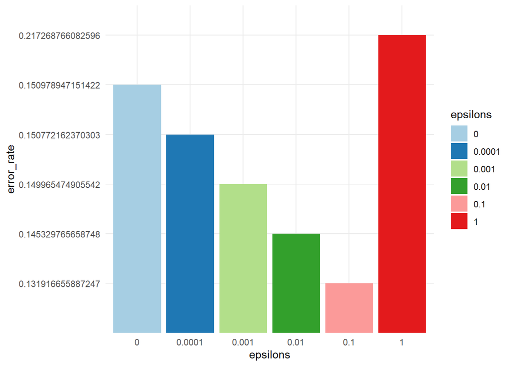

```r
# Try different epsilons to see if model accuracy can be further improved

epsilons <- c("0", "0.0001", "0.001", "0.01", "0.1", "1")
svm_model_epsilon <- list()
predict_training_epsilon <- list()
error_epsilon <- NULL
svm_RMSE_epsilon <- NULL
suppressWarnings(
for (epsilon in epsilons) {
  svm_model_epsilon <- svm(unemployment_rate~., data = training_data, cost = 5,
                           epsilon = epsilon)
  predict_training_epsilon <- predict(svm_model_epsilon, test_data)

  # store errors

  error_epsilon[epsilon] <- predict_training_epsilon - test_data$unemployment_rate
  svm_RMSE_epsilon[epsilon] <- rmse(error_epsilon)

}
)
epsilon_error_df <- data.frame(cbind(epsilons, svm_RMSE_epsilon))
colnames(epsilon_error_df)[2] <- "error_rate"
epsilon_error_df$epsilons <- as.factor(epsilon_error_df$epsilons)
epsilon_error_df$error_rate <- as.factor(epsilon_error_df$error_rate)



epsilon_error_df <- epsilon_error_df %>%
  arrange(error_rate)

ggplot(epsilon_error_df, aes(x = epsilons, y = error_rate, fill = epsilons)) +
  geom_bar(stat = "identity") +
  scale_fill_brewer(palette="Paired") +
  theme_minimal()
```

### Kernel

SVM algorithms use a set of mathematical functions that are defined as the kernel. The function of kernel is to take data as input and transform it into the required form. Different SVM algorithms use different types of kernel functions. Model tuning of the “radial”, “linear”, “polynomial”, “sigmoid” kernels was undertaken using the below code.

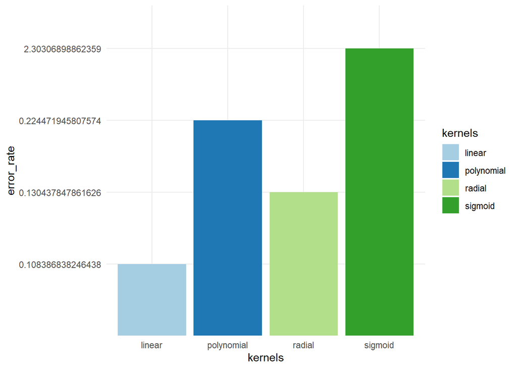

```r
# Try different kernals to see if model accuracy can be further improved

kernels <- c("radial", "linear", "polynomial", "sigmoid")
svm_model_kernel <- list()
predict_training_kernel <- list()
error_kernel <- NULL
svm_RMSE_kernel <- NULL
suppressWarnings(
for (kernel in kernels) {
  svm_model_kernel <- svm(unemployment_rate~., data = training_data, cost = 5,
                          kernel = kernel, epsilon = 0.01)
  predict_training_kernel <- predict(svm_model_kernel, test_data)

  # store errors

  error_kernel[kernel] <- predict_training_kernel - test_data$unemployment_rate
  svm_RMSE_kernel[kernel] <- rmse(error_kernel)

}
)
kernel_error_df <- data.frame(cbind(kernels, svm_RMSE_kernel))
colnames(kernel_error_df)[2] <- "error_rate"
kernel_error_df$kernels <- as.factor(kernel_error_df$kernels)
kernel_error_df$error_rate <- as.factor(kernel_error_df$error_rate)



kernel_error_df <- kernel_error_df %>%
  arrange(error_rate)

ggplot(kernel_error_df, aes(x = kernels, y = error_rate, fill = kernels)) +
  geom_bar(stat = "identity") +
  scale_fill_brewer(palette="Paired") +
theme_minimal()
```

### SVR tuned results

These values were then added as values to the svm function and the prediction was then plotted against the **Actual** unemployment_rate values:

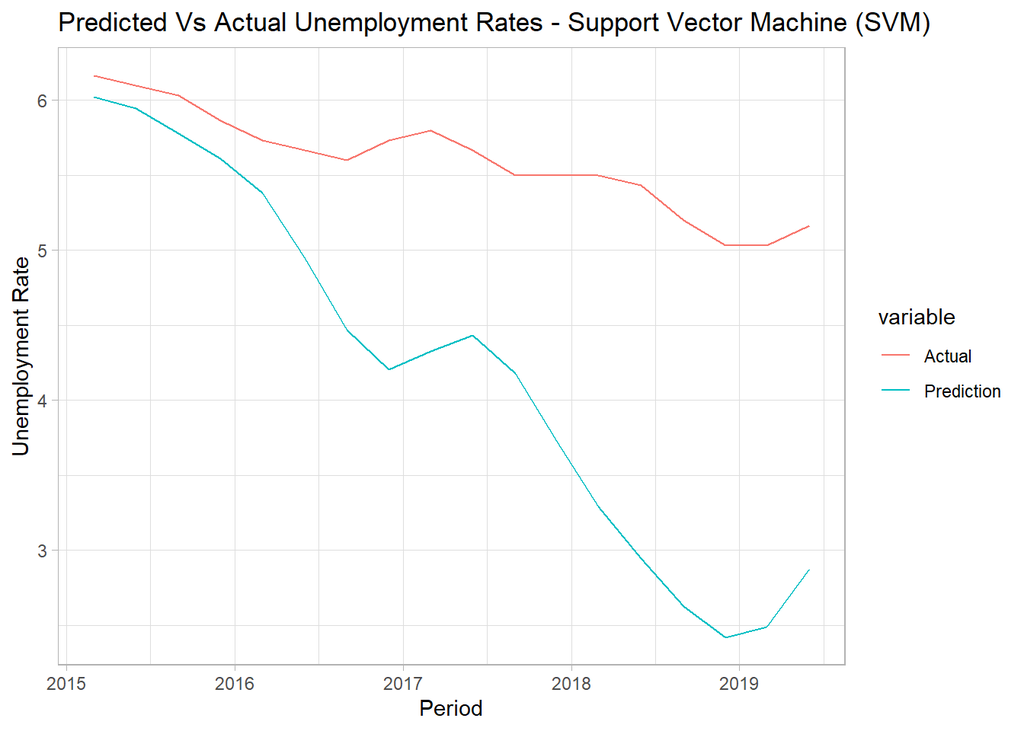

```r
svm_RMSE_test
```

```
## [1] 0.9198836
```

## Artificial Neural Network (ANN)

ANNs are brain inspired systems which are intended to replicate the way that we humans learn. Neural networks consist of input and output layers, as well as hidden layer’s consisting of units that transform the input into something that the output layer can use. In this report we will be using the **neuralnet()** function from the **neuralnet** package. As part of this model we are able to tune the model using several hyper parameters. The configuration of the hidden layers being one of them. We will also be tuning the activation function as discuss the different options that are able to be used as part of this package.

### Hidden Layers

A hidden layer is located between the input and output of the network, in which the function applies weights to the inputs and directs them through an activation function as the output. We can observe a visual of a neural network consisting of a network of an input layer, 2 hidden layers and the output layer.

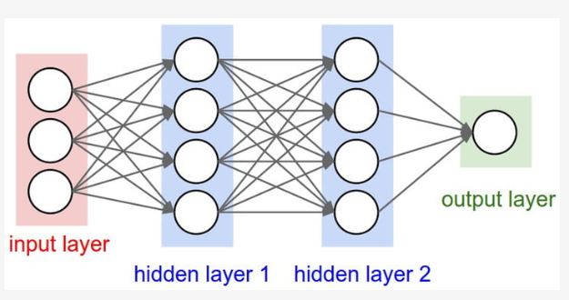

Neural Network

The first model that was executed against the training data consisted of 2 hidden layers, the first with **2 neurons** and the second with a single neuron. The result of this was that the model wasn’t able to converge as it hit the default limit of steps it can take in converging. Increasing this to 1e7 we are able to get an error rate of **0.1923948**

```r
set.seed(112)
nn_training <- neuralnet(unemployment_rate ~ .,
                         data=training_data,
                         hidden=c(2,1),
                         linear.output=TRUE,
                         threshold=0.01,
                         learningrate = 0.01,
                         stepmax = 1e7)
nn_predict_training <- predict(nn_training, training_data)
nn_error_training <- nn_predict_training - training_data$unemployment_rate
nn_RMSE_training <- rmse(nn_error_training)
nn_RMSE_training
```

```
## [1] 0.1923948
```

We can try this configuration again the test data which gives an error rate of **0.67028**

```r
set.seed(112)
nn_testing <- neuralnet(unemployment_rate ~ .,
                        data=training_data,
                        hidden=c(2,1),
                        linear.output=TRUE,
                        threshold=0.01,
                        learningrate = 0.01,
                        stepmax = 1e7)
nn_predict_test <- predict(nn_testing, test_data)
nn_error_test <- nn_predict_test - test_data$unemployment_rate
nn_RMSE_test <- rmse(nn_error_test)
nn_RMSE_test
```

```
## [1] 0.67028
```

As mentioned earlier, we are able to tune the model based on these hidden layers. Various configurations were used and their error rates can be observed below:

|  | error_rate |
| --- | --- |
| 2 Layers - (3,1) | 0.2318359 |
| 2 Layers - (16,8) | 0.2151058 |
| 2 Layers - (64,32) | 0.5006262 |
| 2 Layers - (5,1) | 0.1268098 |
| 3 Layers - (5,2,1) | 0.3628558 |

Using the configuration from the lowest error rate we can then further tune the model to configure the activation function.

## Activation function

The activation function within a neural network facilitates the conversion of inputs into derived features . In other terms, the activation function of a node defines the output of that node given an input. It is a non-linear function applied by a neuron to introduce non-linear properties in the network. A network without non-linearity is essentially just a linear regression model. A visual between linear and non-linearity can be seen below, by introducing non-linearity we can better capture the patterns in this data:

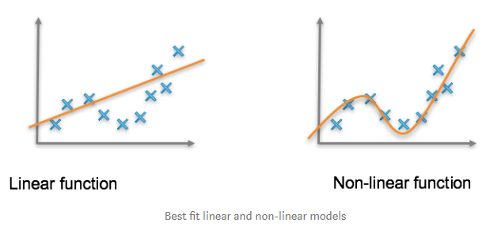

Linear vs Non-Linear

### Sigmoid

The sigmoid activation function can also be referred to as the logistic activation function is a differentiable function in which we are able to find the slope of the sigmoid curve at any two points. It transforms the input data into a value between 0 and 1 for processing and is is strong with probability based networks as a probability value exists between 0 and 1.

The function mathematical notation can be represented as:

$\operatorname{sigmoid}(z)=\frac{1}{1+e^{-z}}$

A custom function was developed and used within the **neuralnet()** function against the **act.fct** argument

### Tanh or hyperbolic tangent Activation Function

Tanh is similar to sigmoid however it transforms the input from -1 to 1. The benefits of this is that negative input data will be mapped strongly negative and the zero inputs will be mapped near zero.

The function mathematical notation can be represented as:

$\tanh (z)=\frac{e^{z}-e^{-z}}{e^{z}+e^{-z}}$

### Softplus

Softplus is a type of Rectified Linear Unit (ReLU) function which takes the form of $f(x)=\ln \left(1+e^{x}\right)$. What is interesting with the Softplus is that the derivative of the function is the logistic function expressed in the Sigmoid section. A custom function was created and then the variable used in the **neuralnet()** package for modelling.

### Neural network tuned results

The softplus activation function gave us the best result with an error rate of **0.0968178**

|  | error_rate |
| --- | --- |
| sigmoid | 0.1268098 |
| tanh | 0.4012690 |
| softplus | 0.0968178 |

We can plot the neural network and see the input later with all variables of the data, 2 hidden layers - the first layer containing 5 nodes and the second containing a single node, and the output layer of the node. As discussed briefly the output of the network is computed by multiplying the input (x) by the weight (w0) and passing the result through an activation function. In this case the Softplus was obviously chosen. The black arrows are the weights, which can be considered as how much that variable contributes to the next node. The blue nodes and the blue lines are the bias that was introduced into the model. The **bias neuron** is a neuron that is added to each layer in the network which allows the model to move or translate the activation function left or right. Often the model will need to move the entire activation function to generate the required output values.

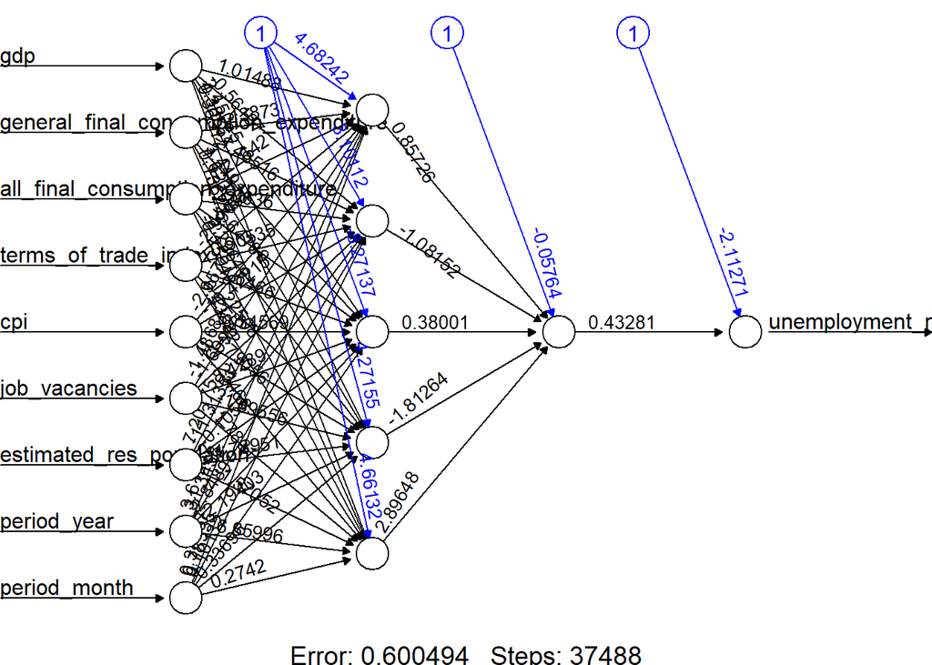

If we plot the data against the original data we are able to see how the model performs with its prediction

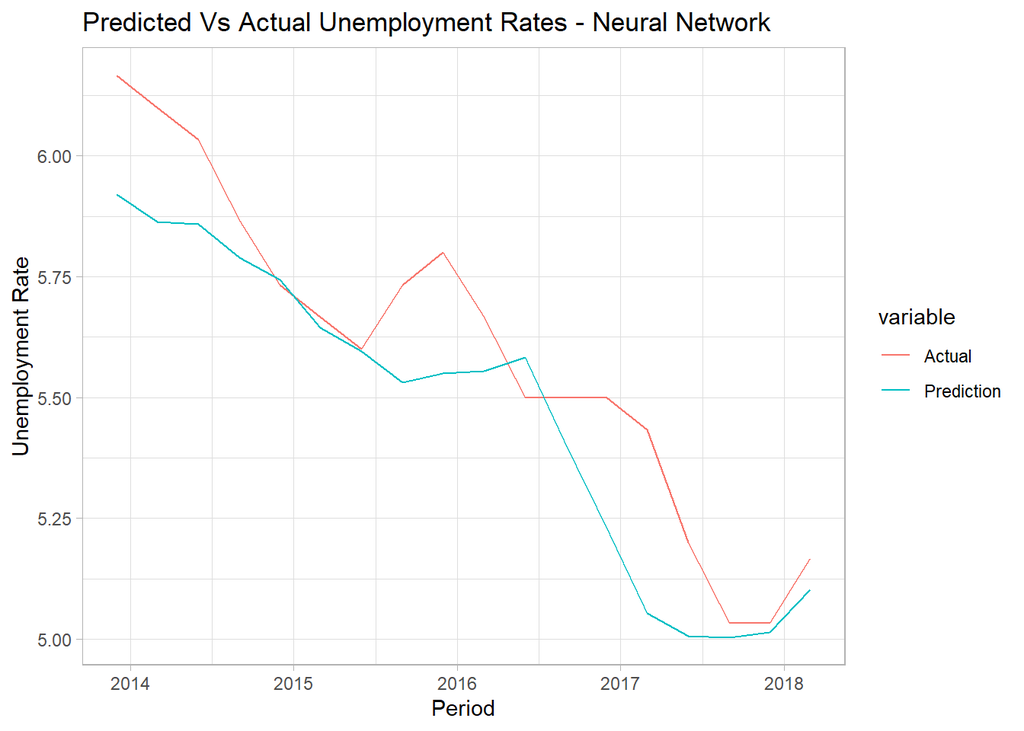

## Comparison and Contrasting SVR and NN models

The neural network performed much better and once again trends a similar linearity with the actual data. The error is still quite high, sitting at **0.0968178**.

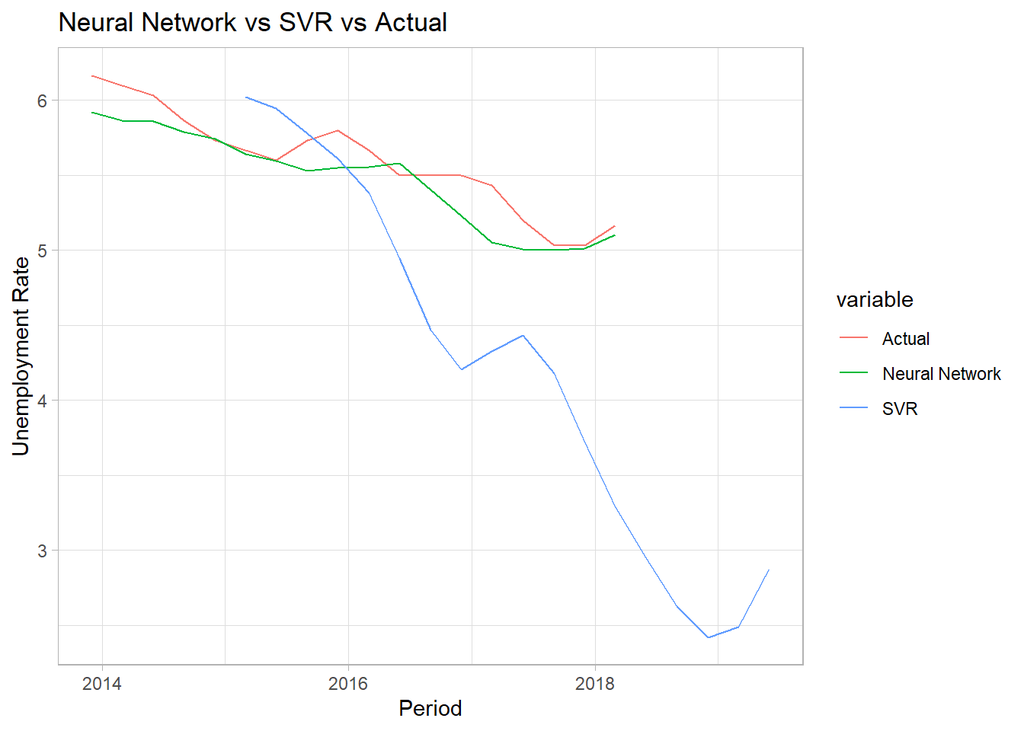

### Conclusions

Learning about SVR and the differences between gamma, cost and epsilon was valuable experience for myself. SVM’s and SVR’s generally perform better in high dimensionality and therefore it is possible that a random forest may have given a more accurate prediction on this dataset. The neural network is clearly the superior model against this data. The tuning of the models was an extremely important exercise as the difference between the accuracy of the models pre and post tuning was significant.

Based on the performance of the neural network, a re-write using some of the deep learning libraries would be a good recommendation. There are additional hyper parameters which can be used and there is a bit more flexibility too. Further Relu functions could be used as well as using both forward and back propagation to see whether model accuracy could be further improved. Another recommendation would be to see whether the source data could be sourced at a month level. Having this extra layer of granularity might assist the model as it will have more data points to work off.

# References

https://www.infochoice.com.au/rate-watch/history-of-interest-rate-movements/ https://www.abs.gov.au/ausstats/abs@.nsf/0/6050C537617B613BCA25836800102753?Opendocument https://www.investopedia.com/articles/economics/12/okuns-law.asp https://www.abs.gov.au/about?OpenDocument&ref=topBar https://data-flair.training/blogs/svm-kernel-functions/#:~:text=SVM%20algorithms%20use%20a%20set,functions%20can%20be%20different%20types. https://towardsdatascience.com/an-introduction-to-support-vector-regression-svr-a3ebc1672c2 https://www.digitaltrends.com/cool-tech/what-is-an-artificial-neural-network/ https://medium.com/@srnghn/deep-learning-overview-of-neurons-and-activation-functions-1d98286cf1e4 https://towardsdatascience.com/activation-functions-neural-networks-1cbd9f8d91d6 https://medium.com/@abhinavr8/activation-functions-neural-networks-66220238e1ff